# Pubpol 543 Final Project

Data Analysis between Society and Enviroment by CEB Visualization Team

Cheng-Wei Lin, Elizabeth Perkins, and Ben Crawley

3/16/2020

```
## Linking to liblwgeom 3.0.0beta1 r16016, GEOS 3.7.2, PROJ 5.2.0
```

# Background

Our analysis of society and the enviroment takes the factors that drive climate change and analyze how they drive country CO2 emissions. Carbon footprints were analyzed using the following factors or their national equilivants:

- Income
- Geography
  - The urban vs rural divide
- Socioeconomic Indicators
  - Age
  - Education
  - Household size

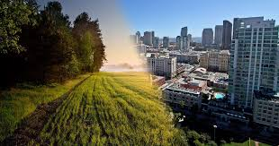

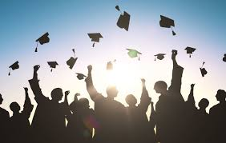

## Data Sources

#### World Bank (2018)

- Metric tons of CO2 emissions per Capita, electricity consumption, and Gross Domestic Product per Capita

#### Human Development Index (HDI)

- United Nations
- Life Expectancy, Years of Schooling, and Gross National Income per Capita

#### Population

- WorldOMeter
- Population, Migration, Urban Population, Population Density, Land Area

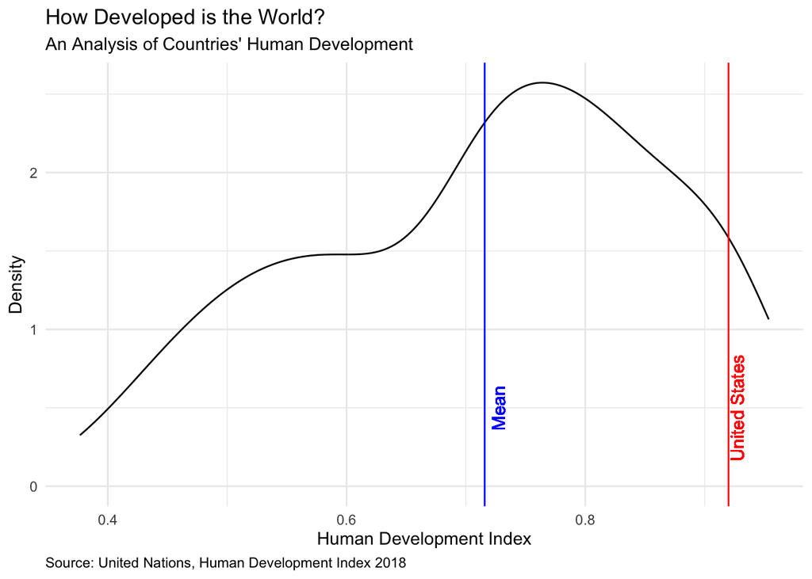

This plot analyzes the Human Development Index (HDI) to see how developed countries generally are. The index is on a scale from 0-1, where a higher score means the country is more developed. The mean development score for all countries is 0.72. As you can see on the plot, there is actually a large concentration of countries that are just above the mean with high development. The United States specifically is scored highly, at 0.92. The countries below the mean are more spread out with a larger variance of development.

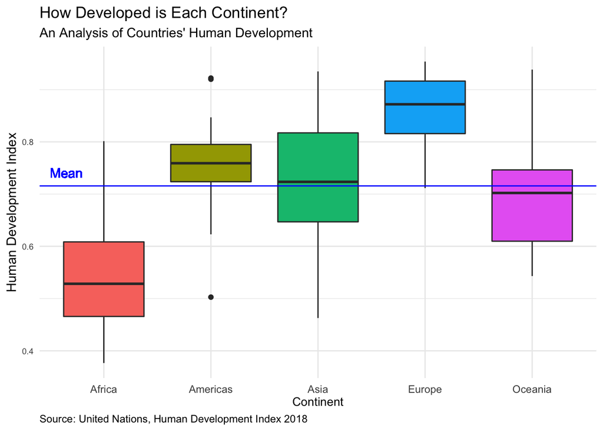

Here we can see the HDI broken out across each continent.This shows a few things about development across the world:

- The Americas and Europe are almost completely above the mean development score;
- Asia and Oceania are centered almost at the mean;
- Africa is solidly below the mean, which makes sense as there are many developing nations there.

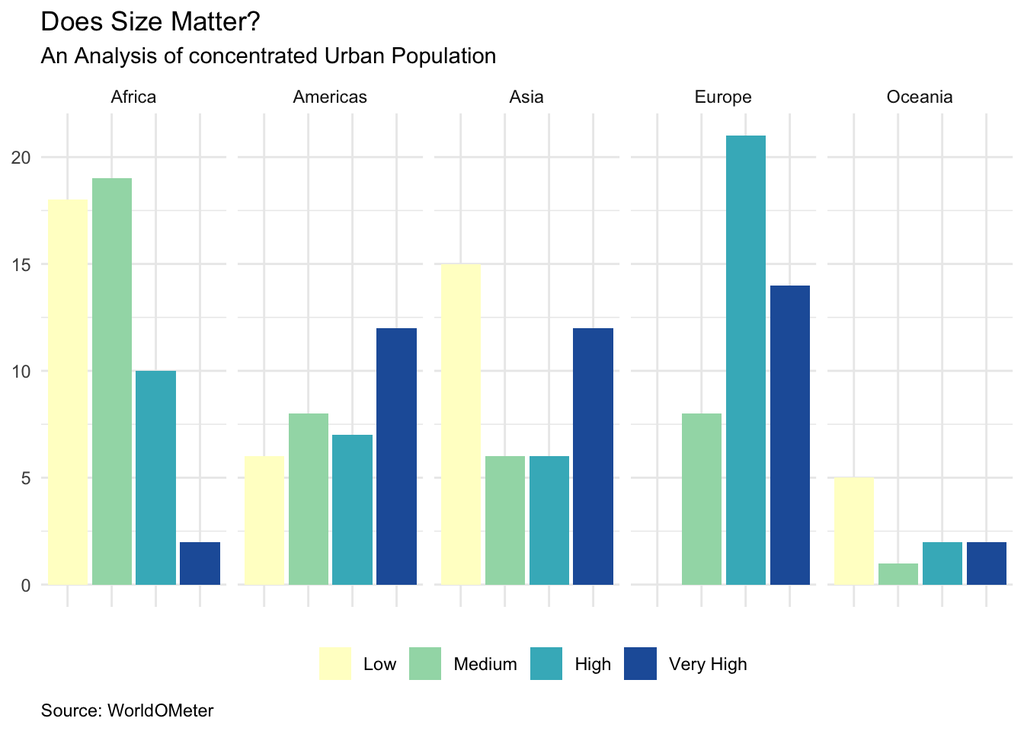

This plot compares the categories of the percentage of urban population between continents. We used the percentage of urban population as our variable to understand the urban and rural divide associated with greenhouse gas emissions. To note a few key pieces about this graph:

- Africa is largely rural.
- North and South America has been combined into Americas.
- Asia has a large divide between rural and highly urbanized countries.
- Europe is the most highly urbanized continent.
- Oceania has the fewest overall countries which is why there is a relative drop compared to the other continents.

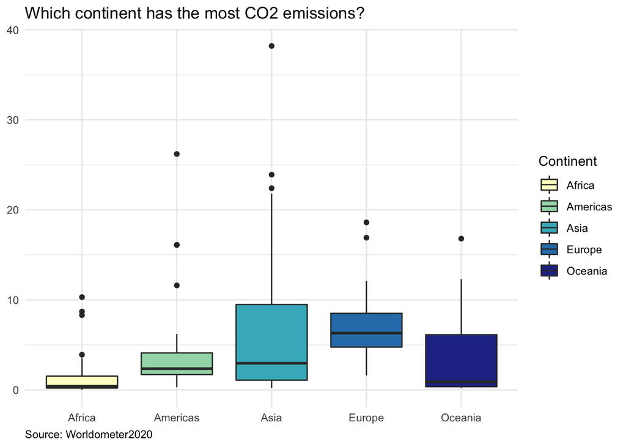

We label the continent and plot the univariate column: Emissions

Apparently, Africa is the one which produce the least CO2 emissions. As for rest of them, we could see at Asia and Europe first, these two continent’s top 25 percent countries emit almost the same amount of carbon dioxide. However, when you take a closer look, the Asia’s median is weigh lower than Europe. This result shows that the amount of carbon dioxide emitted by Asian countries varies widely, while the European countries emit the same amount of carbon dioxide.

For most of Americas countries, they do not emit huge amount of CO2 emission, however, just as Asia, the outliers are many times higher than standard deviation

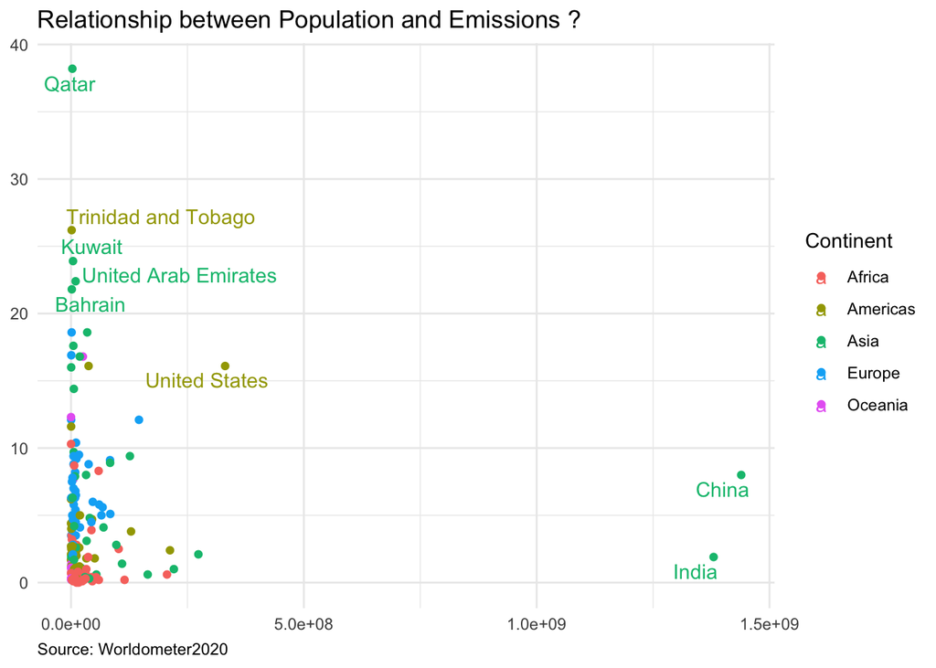

We want to know the relationship between emissions and population. Therefore, we choose a scatter plot. In order to follow ‘keep it simple’ approach, so I use theme_minimal() to keep the background clear. After plotting, we found out that there’s no obvious correlated between them. Therefore, we decided to do a boxplot.

Only label the country which emissions and population is above 3rd Qu.

From this scatter plot, we notice that all of the points gather in the left corner. Also, there are lots of outliers.

In this case, it would be hard to tell whether emissions and population is correlated. Therefore, we would like to know will is be any difference if we choose to use the column category of the population instead of population.

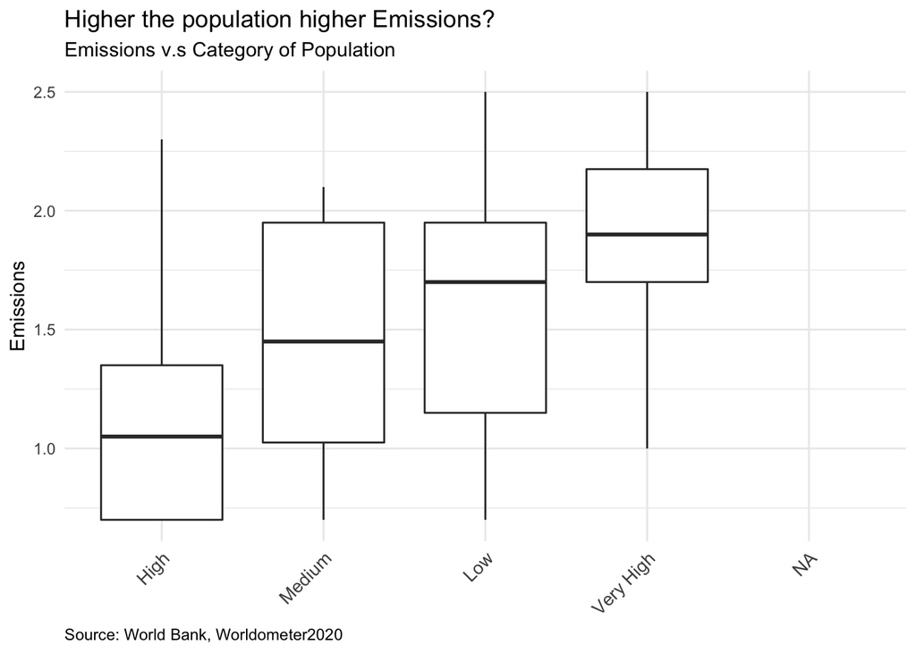

Before we saw the result from our plot, we always assume more people, more carbon dioxide emissions, vise versa. However, it might not always be the true.

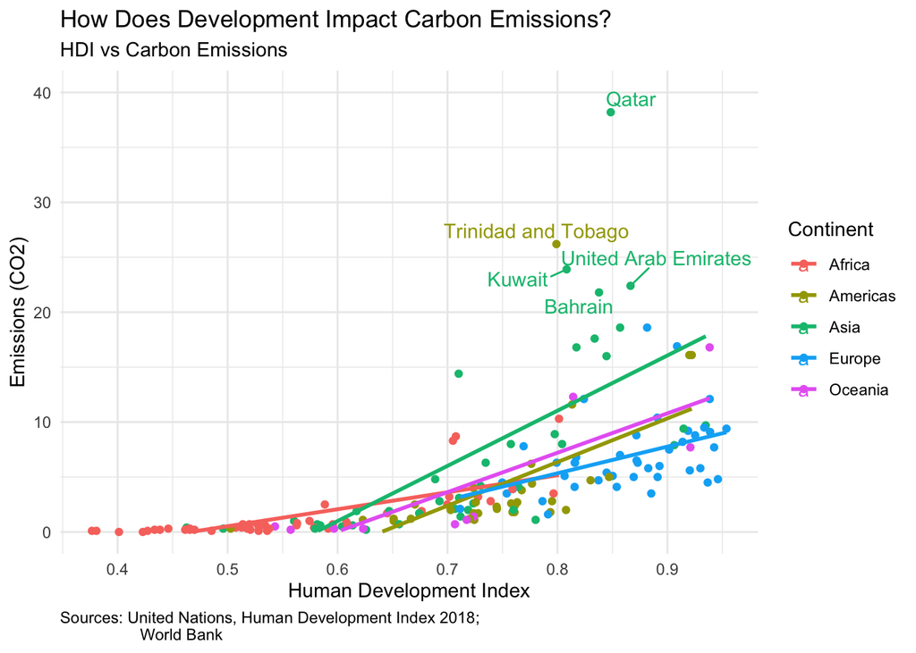

In this first bivariate analysis, it was important to see the relationship between development and carbon emissions. We speculated that more developed countries would produce higher emissions, as they drive more cars and have more industrial capacity. This scatterplot shows a clear trend that supports this. As the HDI score increases, carbon emissions also increases. The regression lines, broken out by continent, further shows this relationship.

There are several outliers (Qatar, UAE, Kuwait, Bahrain, Trinidad and Tobago) with emissions over 20 tons/capita. Almost all of these outliers belong ot the Middle East and are oil producing countries, so it is not surprising that their emissions are extremely high for their development.

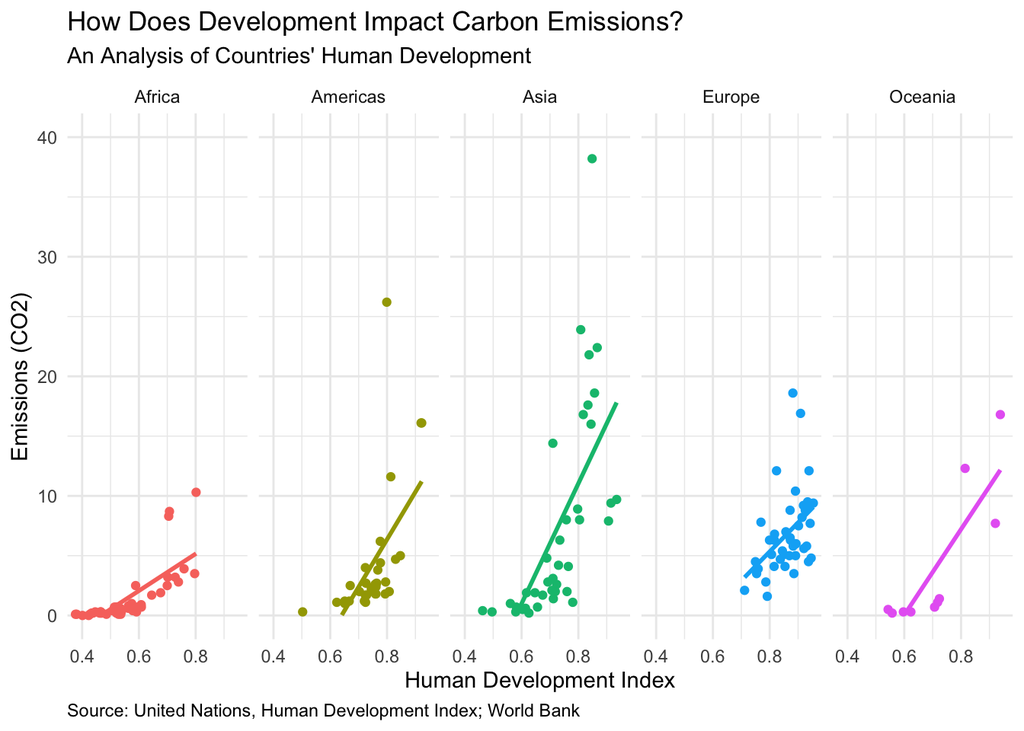

Here the previous scatterplot is further broken out by continent to see each continent’s trends. The relationship established previously holds true across each continent. However, the Asian continent (largely brought up by the Middle East) appears to produce a lot more emissions for higher development scores than other continents.

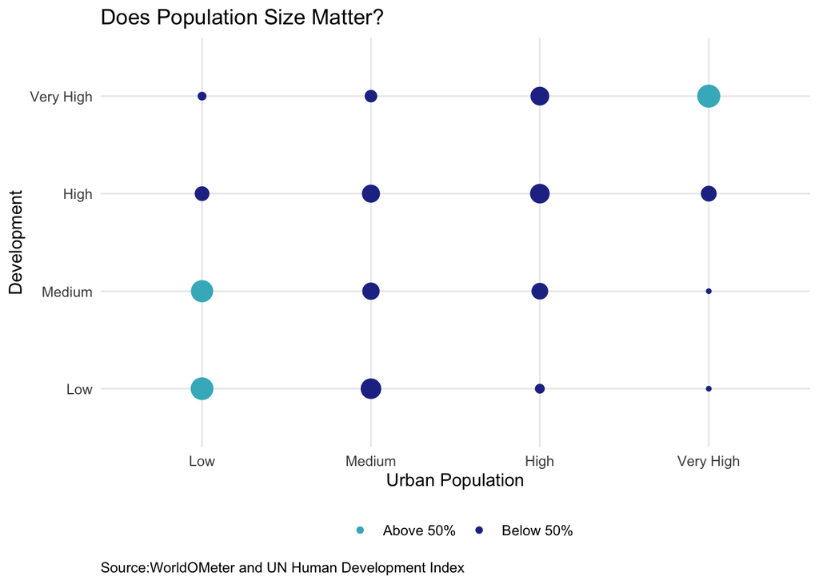

Having a larger proportion of urban population is associated with higher development. In the graph above we highlighted the key intersection between urban population and the HDI development scores with a concentration threshold of 50 percent.

These intersections follow our expectations with low urbanization and low or medium development being above 50 percent. Additionally, high urbanization and high development being above 50 percent. We expected that the concentration of the population would scale with increased Gross National Income and would require the support structure associated with other development factors.

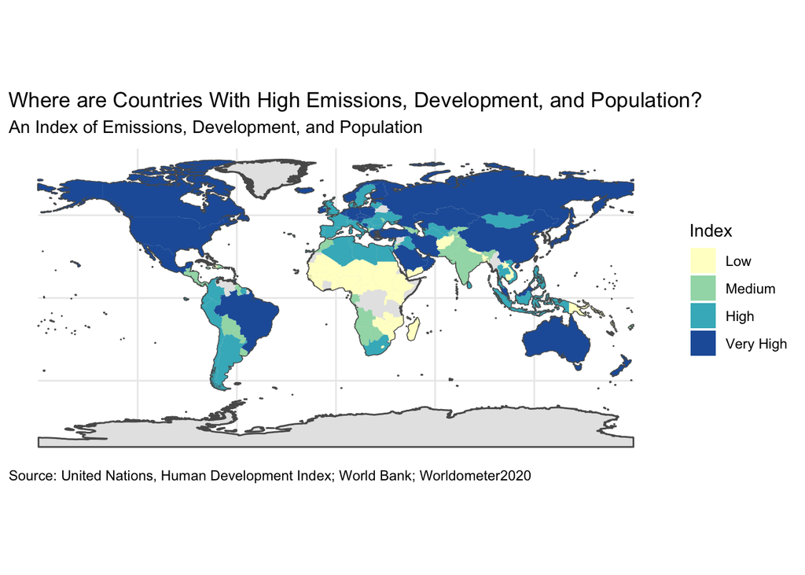

Finally, to summarize our findings we created a new index composed of the HDI, Carbon Emissions per Capita, and Population. Dark blue represents countries with a higher combined development score, carbon emissions output, and population. Conversely, countries in yellow score lower on this combined index.

- To no surprise, countries that score highest on this index are in North America, Europe, and the larger, industrial countries in Latin America and Asia.
- Lower scored countries are predominately in developing areas of Africa and Asia, where populations are more rural, development is low, and are less industrialized.